# Analysis of Storm Data across United States

Robert Jonczy

18.06.2015

## Synopsis

This analysis focuses on analysis the U.S. National Oceanic and Atmospheric Administration’s (NOAA) storm database to find out what events are most harmful with respect to population health and what events have the greatest economic consequences.

## Data processing

### Downloading and loading data

Storm Data is downloaded from [here](http://d396qusza40orc.cloudfront.net/repdata%2Fdata%2FStormData.csv.bz2)

Downloading data if it was not found in local folder and loading into dataframe `storm_data` if it was not found in memory.

```r
if(!file.exists('./stormdata.csv.bz2')) {
    download.file("http://d396qusza40orc.cloudfront.net/repdata%2Fdata%2FStormData.csv.bz2", destfile = 'stormdata.csv.bz2')
}

if(!exists('storm_data')) {
    storm_data <- read.csv(bzfile('./stormdata.csv.bz2'))
}
```

### Data preparation

I am loading additional libraries like: [dplyr](http://cran.r-project.org/web/packages/dplyr/index.html) and [knitr](http://cran.r-project.org/web/packages/knitr/index.html) and suppress warning messages.

```r
suppressWarnings(suppressMessages(library(knitr)))
suppressWarnings(suppressMessages(library(dplyr)))
storm_data <- select(storm_data, EVTYPE, FATALITIES, INJURIES, PROPDMG, CROPDMG)
storm_data <- mutate(storm_data, TOTALDMG = PROPDMG + CROPDMG)
storm_data <- mutate(storm_data, TOTALFATINJ = FATALITIES + INJURIES)

fatinj <- aggregate(storm_data$TOTALFATINJ, list(storm_data$EVTYPE), sum)
names(fatinj) <- c('EVTYPE','SUMINJURIES')
fatinj <- arrange(fatinj, desc(SUMINJURIES))

cost <- aggregate(storm_data$TOTALDMG, list(storm_data$EVTYPE), sum)
names(cost) <- c('EVTYPE','SUMDAMAGES')
cost <- arrange(cost, desc(SUMDAMAGES))
```

## Results

I was trying to answer 2 questions with these analysis:

- Across the United States, which types of events (as indicated in the EVTYPE variable) are most harmful with respect to population health?
- Across the United States, which types of events have the greatest economic consequences?

### Top 10 types of events most harmful with respect to population health

Most harmful events with respect to population health (amount of Injuries and Fatalities) are: **TORNADOS**

```r
library(ggplot2)
summary(storm_data$TOTALFATINJ)
```

```
##      Min.   1st Qu.    Median      Mean   3rd Qu.      Max.
##    0.0000    0.0000    0.0000    0.1725    0.0000 1742.0000
```

```r
kable(head(fatinj, 10))
```

| EVTYPE | SUMINJURIES |
| --- | --- |
| TORNADO | 96979 |
| EXCESSIVE HEAT | 8428 |
| TSTM WIND | 7461 |
| FLOOD | 7259 |
| LIGHTNING | 6046 |
| HEAT | 3037 |
| FLASH FLOOD | 2755 |
| ICE STORM | 2064 |
| THUNDERSTORM WIND | 1621 |
| WINTER STORM | 1527 |

```r
fatinj <- head(fatinj, 10)
```

Above data has been visualise on histogram:

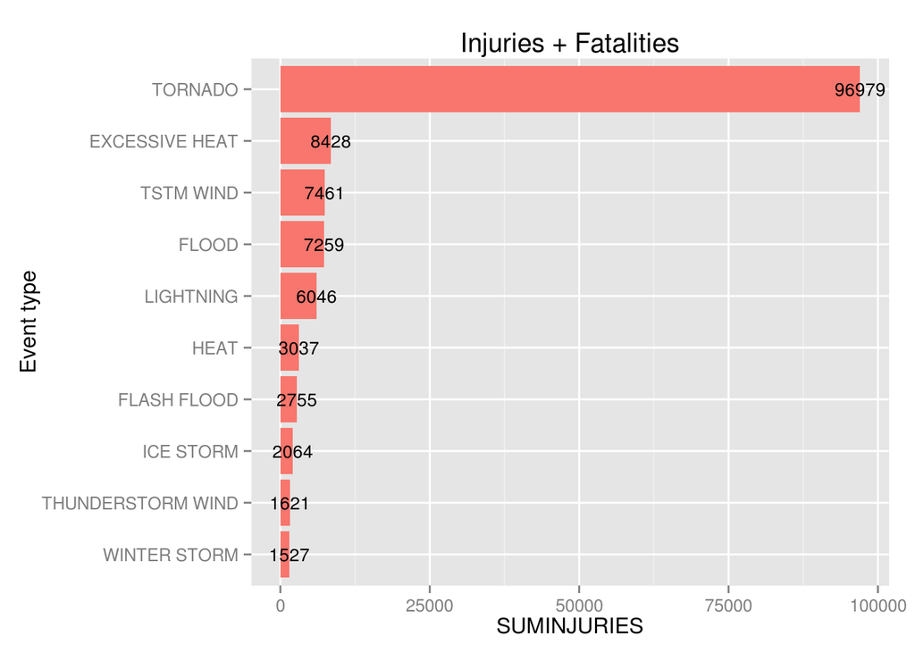

```r
ggplot(fatinj, aes(x = reorder(EVTYPE, SUMINJURIES), y = SUMINJURIES, fill = "red")) +
    geom_bar(stat="identity") +
    geom_text(aes(label = SUMINJURIES, size=0.5)) +
    coord_flip() +
    ggtitle("Injuries + Fatalities") +
    xlab("Event type") +
    theme(legend.position = "none")
```

### Top 10 types of events with greatest economic consequences

```r
summary(storm_data$TOTALDMG)
```

```
##    Min. 1st Qu.  Median    Mean 3rd Qu.    Max.
##    0.00    0.00    0.00   13.59    1.00 5000.00
```

```r
kable(head(cost, 10))
```

| EVTYPE | SUMDAMAGES |
| --- | --- |
| TORNADO | 3312276.7 |
| FLASH FLOOD | 1599325.1 |
| TSTM WIND | 1445168.2 |
| HAIL | 1268289.7 |
| FLOOD | 1067976.4 |
| THUNDERSTORM WIND | 943635.6 |
| LIGHTNING | 606932.4 |
| THUNDERSTORM WINDS | 464978.1 |
| HIGH WIND | 342014.8 |
| WINTER STORM | 134699.6 |

Greatest economic consequences in United States cause: **TORNADOS**